# Educational simulation: event-study and difference-in-differences in R

2026-09-17

# Measuring behaviour change with an event-study / difference-in-differences

## Introduction

A common question in Copilot Analytics is *causal*: **did a person’s collaboration behaviour actually change after they started using Copilot**, or are heavy users simply different people to begin with? A plain comparison of users vs non-users cannot separate the two, because adoption is not random.

This **educational, homogeneous-effect simulation** illustrates a within-person event-study and a **two-way fixed-effects (TWFE) DiD** model. It is **not a supported real-data causal recipe**. In this simulated design, the model:

- aligns every adopter on their own **event time** (weeks relative to the week they adopted Copilot),
- compares adopters against a control group of non-adopters over the same calendar weeks,
- absorbs each person’s baseline (**person fixed effects**) and every calendar week’s common shocks (**week fixed effects**), and
- reads the treatment effect as the *within-person* change in the treated group relative to the control group.

Treatment assignment, full observation and constant post-adoption effects are known by construction here. TWFE can also compare earlier and later adopters; retaining never-adopters does not turn it into a never-treated-only estimator. Heterogeneous staggered effects can invalidate its interpretation. Real-data use requires a separate review of treatment timing, eligibility, missingness, attrition, selection, spillovers, parallel trends and the appropriate estimator. First observed activity is not generally the same as actual adoption.

## Set-up

This example uses **fixest** for fast fixed-effects estimation; install it with `install.packages("fixest")` if you do not already have it.

```r
knitr::opts_chunk$set(warning = FALSE, message = FALSE)
library(dplyr)
library(tidyr)
library(ggplot2)
library(scales)
library(fixest)   # fast fixed-effects estimation (feols, i(), iplot)
```

Analysis configuration is independent of the simulator’s known effect.

```r
WINDOW <- 8L
components <- c("Collaboration_hours", "Chat_hours", "Emails_sent")
```

## Simulate a Person-Query-shaped panel

The block below creates a weekly panel with the same shape as a Person Query: one row per `PersonId` x `MetricDate`, a `Total_Copilot_actions_taken` column, and a few collaboration outcomes (`Collaboration_hours`, `Chat_hours`, `Emails_sent`). Treated people adopt Copilot at a **staggered** week; control people never adopt. We add person baselines, calendar-week seasonality, and noise so the panel looks realistic.

The panel resembles a Person Query for teaching purposes; matching column names is not evidence that an export satisfies the design assumptions.

```r
set.seed(100)

n_persons <- 400L
n_weeks   <- 40L
weeks     <- seq(as.Date("2024-01-01"), by = "week", length.out = n_weeks)

# ---- clearly-labelled illustrative effect ---------------------------------
# DEMO ONLY: this is the size of the behaviour change we inject into treated
# people after adoption. This constant is used only in the simulator.
TREATMENT_EFFECT <- 0.8   # extra collaboration hours/week once adopted
# ---------------------------------------------------------------------------

persons <- tibble(
  PersonId    = sprintf("P%04d", seq_len(n_persons)),
  treated     = rbinom(n_persons, 1, 0.6),
  # person baseline (some people simply collaborate more than others)
  base_collab = rnorm(n_persons, mean = 12, sd = 3)
)

# Treated people adopt at a staggered week (10..28); controls never adopt.
persons <- persons %>%
  mutate(adopt_week = ifelse(
    treated == 1,
    sample(10:28, n_persons, replace = TRUE),
    NA_integer_
  ))

# calendar-week seasonality shared by everyone
week_shock <- tibble(
  week_idx  = seq_len(n_weeks),
  MetricDate = weeks,
  season    = 1.5 * sin(2 * pi * seq_len(n_weeks) / 26)
)

panel <- tidyr::crossing(PersonId = persons$PersonId, week_idx = seq_len(n_weeks)) %>%
  left_join(persons, by = "PersonId") %>%
  left_join(week_shock, by = "week_idx") %>%
  mutate(
    adopted_now = treated == 1 & week_idx >= adopt_week,
    # Copilot actions: 0 before adoption, positive afterwards (treated only)
    Total_Copilot_actions_taken = ifelse(
      adopted_now, rpois(n(), lambda = 25), 0L
    ),
    # primary outcome: baseline + season + injected effect (post-adoption) + noise
    Collaboration_hours = base_collab + season +
      ifelse(adopted_now, TREATMENT_EFFECT, 0) +
      rnorm(n(), 0, 2),
    # two correlated collaboration outcomes for the composite index later
    Chat_hours  = 0.35 * Collaboration_hours + rnorm(n(), 0, 0.8),
    Emails_sent = 20 + 1.2 * Collaboration_hours + rnorm(n(), 0, 4)
  ) %>%
  select(PersonId, MetricDate, week_idx, treated,
         Total_Copilot_actions_taken,
         Collaboration_hours, Chat_hours, Emails_sent)

head(panel)
```

```
## # A tibble: 6 × 8
##   PersonId MetricDate week_idx treated Total_Copilot_actions_taken
##   <chr>    <date>        <int>   <int>                       <int>
## 1 P0001    2024-01-01        1       1                           0
## 2 P0001    2024-01-08        2       1                           0
## 3 P0001    2024-01-15        3       1                           0
## 4 P0001    2024-01-22        4       1                           0
## 5 P0001    2024-01-29        5       1                           0
## 6 P0001    2024-02-05        6       1                           0
## # ℹ 3 more variables: Collaboration_hours <dbl>, Chat_hours <dbl>,
## #   Emails_sent <dbl>
```

```r
cat(sprintf("Injected simulation effect: %+.2f hours/week\n", TREATMENT_EFFECT))
```

```
## Injected simulation effect: +0.80 hours/week
```

## Derive the adoption week and event time

In this complete simulated panel, first activity identifies adoption. This is a property of the simulator, not a real-data identification rule. Adopters retain their ±8-week windows. Never-adopters retain **all calendar weeks present in those windows**, rather than being trimmed around an arbitrary placebo date.

```r
stopifnot(all(c("PersonId", "MetricDate", "Total_Copilot_actions_taken",
               components) %in% names(panel)),
          !anyNA(panel[c("PersonId", "MetricDate", "Total_Copilot_actions_taken")]),
          !anyDuplicated(panel[c("PersonId", "MetricDate")]))
adopt <- panel %>%
  filter(Total_Copilot_actions_taken > 0) %>%
  group_by(PersonId) %>%
  summarise(adopt_date = min(MetricDate), .groups = "drop")

panel <- panel %>%
  left_join(adopt, by = "PersonId") %>%
  mutate(
    is_adopter = !is.na(adopt_date),
    event_week = as.integer((MetricDate - adopt_date) / 7)
  )

adopter_windows <- panel %>%
  filter(is_adopter, event_week >= -WINDOW, event_week <= WINDOW) %>%
  group_by(PersonId) %>%
  filter(n_distinct(event_week) == 2L * WINDOW + 1L) %>%
  ungroup()
control_weeks <- panel %>%
  filter(!is_adopter) %>%
  semi_join(distinct(adopter_windows, MetricDate), by = "MetricDate") %>%
  mutate(event_week = 0L) # inert in interactions: treated_grp is zero
stopifnot(nrow(adopter_windows) > 0, nrow(control_weeks) > 0,
          setequal(adopter_windows$MetricDate, control_weeks$MetricDate))

panel_es <- bind_rows(adopter_windows, control_weeks) %>%
  mutate(
    treated_grp = as.integer(is_adopter),
    post        = as.integer(is_adopter & event_week >= 0),
    treat_post  = post * treated_grp
  )

panel_es %>%
  distinct(PersonId, treated_grp) %>%
  count(group = ifelse(treated_grp == 1, "Adopter (treated)", "Non-adopter (control)"))
```

```
## # A tibble: 2 × 2
##   group                     n
##   <chr>                 <int>
## 1 Adopter (treated)       238
## 2 Non-adopter (control)   162
```

## The headline TWFE difference-in-differences

The core model is:

$$y_{it} =
\beta\,(\text{post}_{it}\times\text{treated}_i) + \alpha_i + \gamma_t +
\varepsilon_{it}$$

where $\alpha_i$ are person fixed effects, $\gamma_t$ are calendar-week fixed effects, and standard errors are clustered by person. The coefficient $\beta$ on `treat_post` is the difference-in-differences estimate, the within-person change for adopters, net of the control group and of anything common to a given week.

```r
did <- fixest::feols(
  Collaboration_hours ~ treat_post | PersonId + MetricDate,
  data    = panel_es,
  cluster = ~PersonId
)

summary(did)
```

```
## OLS estimation, Dep. Var.: Collaboration_hours
## Observations: 9,716
## Fixed-effects: PersonId: 400,  MetricDate: 35
## Standard-errors: Clustered (PersonId)
##            Estimate Std. Error t value  Pr(>|t|)
## treat_post 0.937315   0.072472 12.9335 < 2.2e-16 ***
## ---
## Signif. codes:  0 '***' 0.001 '**' 0.01 '*' 0.05 '.' 0.1 ' ' 1
## RMSE: 1.96603     Adj. R2: 0.732228
##                 Within R2: 0.019587
```

```r
did_beta <- coef(did)[["treat_post"]]
cat(sprintf(
  "\nDiD estimate: %+.2f collaboration hours/week\n",
  did_beta
))
```

```
##
## DiD estimate: +0.94 collaboration hours/week
```

Compare the estimated coefficient with the separately reported simulation effect. Recovery in this homogeneous simulation is a teaching check, not validation of causal identification on real observations.

## The event-study: check for pre-trends and see the effect emerge

A single DiD number hides a crucial assumption: **parallel trends**. The event-study version estimates a separate coefficient for each event week (relative to week -1, the week before adoption). If the design is valid, the **pre-adoption** coefficients should sit near zero (no divergence before treatment), and the **post-adoption** coefficients should step up to the effect.

`fixest::i()` builds these event-time interactions directly, with `ref = -1` as the omitted reference week.

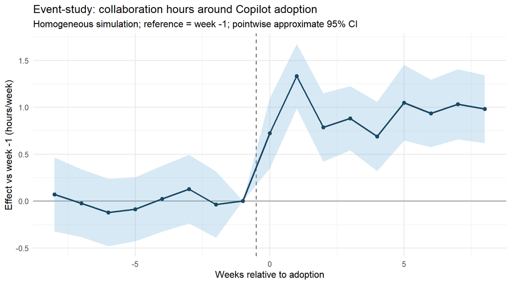

```r
es <- fixest::feols(
  Collaboration_hours ~ i(event_week, treated_grp, ref = -1) |
    PersonId + MetricDate,
  data    = panel_es,
  cluster = ~PersonId
)

# Tidy the event-time coefficients for a ggplot
es_tab <- as.data.frame(coeftable(es))
es_tab$term <- rownames(es_tab)
es_coefs <- es_tab %>%
  filter(grepl("event_week::", term)) %>%
  mutate(
    event_week = as.integer(sub(".*event_week::(-?\\d+).*", "\\1", term)),
    lwr = Estimate - 1.96 * `Std. Error`,
    upr = Estimate + 1.96 * `Std. Error`
  )

# Add the reference week (-1) at exactly 0
es_coefs <- bind_rows(
  es_coefs,
  tibble(event_week = -1, Estimate = 0, lwr = 0, upr = 0)
) %>% arrange(event_week)

ggplot(es_coefs, aes(event_week, Estimate)) +
  geom_hline(yintercept = 0, colour = "grey60") +
  geom_vline(xintercept = -0.5, linetype = "dashed", colour = "grey40") +
  geom_ribbon(aes(ymin = lwr, ymax = upr), fill = "#5fa8d3", alpha = 0.25) +
  geom_line(linewidth = 1, colour = "#1b4965") +
  geom_point(size = 2, colour = "#1b4965") +
  labs(
    title    = "Event-study: collaboration hours around Copilot adoption",
    subtitle = "Homogeneous simulation; reference = week -1; pointwise approximate 95% CI",
    x = "Weeks relative to adoption", y = "Effect vs week -1 (hours/week)"
  ) +
  theme_minimal(base_size = 12)
```

A pre-period trend is a warning, but a flat pre-period is **not proof of parallel trends**: tests can have low power, and TWFE leads can be contaminated under heterogeneous treatment effects. These pointwise intervals are not a joint pre-trend test or simultaneous confidence band.

## Bonus: run the same design on a composite index

Individual metrics can be noisy. An illustrative alternative is to combine several related collaboration metrics into a single **z-scored composite index**, then run the identical DiD on the index. Each component is standardised across the panel (mean 0, sd 1) and averaged, so no single metric’s scale dominates.

```r
zscore <- function(x) (x - mean(x, na.rm = TRUE)) / sd(x, na.rm = TRUE)

panel_es <- panel_es %>%
  mutate(across(all_of(components), zscore, .names = "z_{.col}")) %>%
  mutate(collab_index = rowMeans(across(starts_with("z_")), na.rm = TRUE))

did_index <- fixest::feols(
  collab_index ~ treat_post | PersonId + MetricDate,
  data    = panel_es,
  cluster = ~PersonId
)

summary(did_index)
```

```
## OLS estimation, Dep. Var.: collab_index
## Observations: 9,716
## Fixed-effects: PersonId: 400,  MetricDate: 35
## Standard-errors: Clustered (PersonId)
##            Estimate Std. Error t value  Pr(>|t|)
## treat_post 0.217528   0.019449 11.1843 < 2.2e-16 ***
## ---
## Signif. codes:  0 '***' 0.001 '**' 0.01 '*' 0.05 '.' 0.1 ' ' 1
## RMSE: 0.518178     Adj. R2: 0.666188
##                  Within R2: 0.015253
```

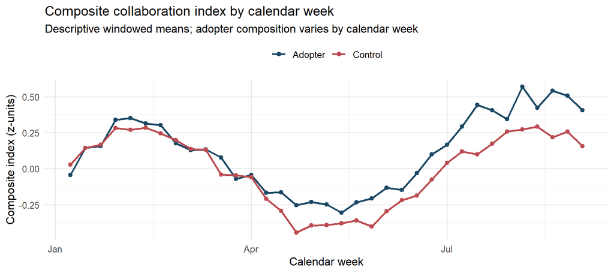

```r
# Calendar time keeps the control comparison on actual shared weeks.
idx_traj <- panel_es %>%
  mutate(grp = ifelse(treated_grp == 1, "Adopter", "Control")) %>%
  group_by(grp, MetricDate) %>%
  summarise(idx = mean(collab_index), .groups = "drop")

ggplot(idx_traj, aes(MetricDate, idx, colour = grp)) +
  geom_line(linewidth = 1) +
  geom_point(size = 1.8) +
  scale_colour_manual(values = c("Adopter" = "#1b4965", "Control" = "#bc4b51"),
                      name = NULL) +
  labs(
    title    = "Composite collaboration index by calendar week",
    subtitle = "Descriptive windowed means; adopter composition varies by calendar week",
    x = "Calendar week", y = "Composite index (z-units)"
  ) +
  theme_minimal(base_size = 12) +
  theme(legend.position = "top")
```

## Wrapping up

This notebook demonstrates the mechanics of TWFE under a known homogeneous simulation. It does not establish that an observational query supports causal inference, nor that a favourable pre-trend plot makes it so. The composite uses full-panel standardisation for illustration; a real study would also need pre-specified components and a defensible, treatment-independent reference scale.